# Dynamic Optimization with Open-Source Tools

Session 2: The Bellman equation on a discrete state

Diego S. Cardoso

University of Illinois Urbana-Champaign

## Workshop roadmap

1. Julia, optimization, and a static reservoir
2. **The Bellman equation on a discrete state**
3. Continuous state: finite and infinite horizon

## Before we start

- Same Codespace as last week. If it is gone, open a new one on the workshop repository
- Files for today, in the `exercises/` folder
  - `s2_inclass.jl`: three blanks that we fill together
  - `s2_homework.jl`: take it further, two blanks, solutions are in `solutions/`
- No JuMP today. Everything is vectors, matrices, loops and one function called `findmax`. We will go back to JuMP next session

## Agenda

1. From one season to many: the Bellman equation, and a finite horizon solved backward
2. Infinite horizon by function iteration
3. Break
4. Policy iteration and simulation

## Sources

- Miranda and Fackler, *Applied Computational Economics and Finance*, Chapter 7: model (Section 7.2.5), algorithms (Section 7.3), calibration and figures (Section 7.6.5)
- [Julia documentation](https://docs.julialang.org/)

# 1. From one season to many

## Last week

One reservoir, one season, $s = 4$. The planner released 93% of the water and beat “irrigate everything” by 8.5%

$$\text{static:}\quad F'(x) = U'(s - x) \qquad\qquad \text{dynamic:}\quad F'(x_t) = U'(s_t - x_t) + \color{#c22}{\delta \, \lambda_{t+1}}$$

A static planner sets the red term to zero. Ninety percent of what water is worth was missing

Today we put it back, and we compute it

## Setting when there is tomorrow

The same reservoir, year after year

- Year $t$ starts with a stock $s_t$. In spring, release $x_t$ for irrigation, farmers receive $F(x_t)$
- Over the summer, recreational users receive $U(s_t - x_t)$
- Over the winter, rain $k$ arrives. Next year starts with $s_{t+1} = \min(s_t - x_t + k, M)$, where $M = 30$ is the capacity. Overflow benefits nobody but has no costs either
- Benefits next year are worth $\delta = 0.9$ of benefits this year

## Model

| State | $s_t \in \{0, 1, \ldots, 30\}$, water at the start of the year |
| --- | --- |
| Control | $x_t \in \{0, 1, \ldots, s_t\}$, released for irrigation |
| Payoff | $f(s, x) = F(x) + U(s - x)$, same $F$ and $U$ as last week |
| Transition | $s_{t+1} = \min(s_t - x_t + k, 30)$ |
| Objective | $\max \sum_{t} \delta^{\,t-1} f(s_t, x_t)$ |

Two simplifications today, both temporary:

- Rain is $k = 2$ every year. The book draws it at random, and so will we in the next session. The book says the algorithms are the same, “provided one views a deterministic model as a special case of the stochastic model” (Section 7.3)
- The capacity $M = 30$ never binds, but we keep it anyway for safety

## Bellman equation

$$V_t(s) = \max_{0 \le x \le s} \Big\{ F(x) + U(s - x) + \delta \, V_{t+1}\big(\min(s - x + k, 30)\big) \Big\}$$

- $V_t(s)$ is the value of holding $s$ units at the start of year $t$, if you choose well from then on
- Today’s release trades $F$ and $U$ now against $\delta V_{t+1}$ of what is left, exactly the missing term

The unknown is not a number but a **function** (i.e., we solve a functional equation)

That sounds hard. On a grid it is not: if $s$ takes 31 values, $V$ is a vector of 31 numbers, and the policy $x^*(s)$ is a vector of 31 integers

## Everything is an integer today

$S = X = \{0, 1, \ldots, 30\}$. A release $x$ is feasible at stock $s$ when $x \le s$

Julia counts from 1, so the stock $s$ lives at index $s + 1$: `S[i]` is `i - 1`, and `S[5]` is the stock 4

So, every time you index a vector by a stock, add one

## Open `s2_inclass.jl`

```julia
α_1 = 14.0;  β_1 = 0.8
α_2 = 10.0;  β_2 = 0.4
δ = 0.9;  M = 30;  k_rain = 2
F(x) = α_1 * x^β_1
U(z) = α_2 * z^β_2
S = 0:M;  X = 0:M # These define sequence of integers from 0 to M
n = length(S);  m = length(X)
```

There are three blanks: two to build the pieces, and one for the Bellman update

## Two pieces

Two matrices, one row per stock, one column per release

- `f[i, k]` is the payoff from releasing `X[k]` when the stock is `S[i]`. When `X[k] > S[i]` the release is impossible, so we store `-Inf` and it never wins a max
- `g[i, k]` is the **index** of next year’s stock: `min(S[i] - X[k] + k_rain, M) + 1`

We are storing the transition as a lookup table. In the next session rain is random and this becomes a probability

## Blanks 1 and 2

```julia
function build_pieces()
    f = zeros(n, m)
    g = zeros(Int, n, m)
    for i in 1:n # Loop over stocks (states)
        for k in 1:m # Loop over releases (actions)
            if X[k] <= S[i]
                f[i, k] = F(X[k]) + U(S[i] - X[k])
                g[i, k] = min(S[i] - X[k] + k_rain, M) + 1
            else
                f[i, k] = -Inf
                g[i, k] = 1
            end
        end
    end
    return f, g
end
f, g = build_pieces();
```

## Look at one row

The stock is 4, so only five releases are possible

```julia
round.(f[5, 1:8], digits = 2)
```

```
8-element Vector{Float64}:
  17.41
  29.52
  37.57
  43.72
  42.44
 -Inf
 -Inf
 -Inf
```

```julia
g[5, 1:8]
```

```
8-element Vector{Int64}:
 7
 6
 5
 4
 3
 1
 1
 1
```

Release nothing and next year’s stock is $4 + 2 = 6$, at index 7. Release 4 and it is $0 + 2 = 2$, at index 3

## A finite horizon solves itself backward

Suppose the world ends after year $T$, so $V_{T+1} = 0$

- Then $V_T(s) = \max_x f(s, x)$: last week’s static problem, on integers
- Then $V_{T-1}$ from $V_T$, then $V_{T-2}$ from $V_{T-1}$, down to $V_1$

No fixed point to find, just a loop that runs backward. In Julia, `for t in T:-1:1`

## Blank 3: the Bellman update

```julia
function backward_recursion(f, g, T)
    V = zeros(n, T + 1)
    x_pol = zeros(Int, n, T)
    for t in T:-1:1
        for i in 1:n
            V[i, t], k_best = findmax(f[i, :] .+ δ .* V[g[i, :], t + 1])
            x_pol[i, t] = X[k_best]
        end
    end
    return V, x_pol
end
```

- `f[i, :] .+ δ .* V[g[i, :], t + 1]` is a vector of 31 candidates, one per release
- `findmax` returns the largest one and its position. The position tells us the release

## Run it at $T = 5$

```julia
T = 5
V_T, x_T = backward_recursion(f, g, T)
for t in 1:T
    println("t = ", t, ": ", x_T[:, t])
end
```

```
t = 1: [0, 0, 1, 1, 1, 1, 1, 2, 2, 2  …  5, 5, 6, 6, 6, 6, 7, 7, 7, 7]
t = 2: [0, 0, 1, 1, 1, 1, 1, 2, 2, 2  …  6, 6, 6, 7, 7, 7, 8, 8, 8, 9]
t = 3: [0, 0, 1, 1, 1, 2, 2, 2, 2, 3  …  7, 7, 8, 8, 8, 9, 9, 10, 10, 11]
t = 4: [0, 0, 1, 1, 2, 2, 2, 3, 3, 4  …  10, 10, 11, 12, 12, 13, 13, 14, 14, 15]
t = 5: [0, 1, 2, 2, 3, 4, 5, 6, 7, 8  …  20, 21, 22, 23, 24, 25, 26, 27, 28, 29]
```

- Year 5 is the last: release nearly everything. That is last week’s planner
- Year 1, with four years ahead: release 1 at $s = 4$, and 7 at $s = 30$

# 2. Infinite horizon by function iteration

## Drop the time subscript

If there is always a next year, nothing distinguishes year $t$ from year $t + 1$, so $V_t = V_{t+1} = V$

$$V(s) = \max_{0 \le x \le s} \Big\{ f(s, x) + \delta \, V\big(\min(s - x + k, 30)\big) \Big\}$$

The same function on both sides, so this is a fixed point, not recursion

One way to find it: start with a guess, apply the right-hand side, and repeat until the vector stops changing: **function iteration** (Section 7.3.2 of Miranda and Fackler)

## Value function iteration recipe

0. Initialize: Start with a guess $v_0(s)$, usually zero
1. Iterate: For each $s$, compute $v_{k+1}(s) = \max_x \{ f(s, x) + \delta \, v_k(\min(s - x + k, 30)) \}$
2. Check: If $\| v_{k+1} - v_k \| < \text{tol}$, stop. Otherwise, go to step 1.

## Coding it

```julia
function value_iteration(f, g; tol = 1e-10, maxit = 1000)
    v_old = zeros(n)
    v_new = zeros(n)
    x_pol = zeros(Int, n)
    for it in 1:maxit # Prevent infinite loops
        for i in 1:n
            v_new[i], k_best = findmax(f[i, :] .+ δ .* v_old[g[i, :]])
            x_pol[i] = X[k_best]
        end
        change = maximum(abs.(v_new .- v_old))
        if it == 1 || it % 32 == 0
            println("  iteration ", it, "   error bound ", δ / (1 - δ) * change)
        end
        v_old = copy(v_new)
        if change < tol
            return v_new, x_pol, it
        end
    end
    return v_new, x_pol, maxit
end
```

Line 7 is blank 3 again, with the time index gone; the rest is just bookkeeping

## Why it works and how long it takes

Since $\delta < 1$ and the payoff is bounded on $[0, 30]$, the update is a **contraction**: every pass shrinks the distance to $V$ by at least a factor $\delta$

The tolerance and the discount rate set an upper bound on the error after $k$ passes:

$$\| v_k - V \| \le \frac{\delta}{1 - \delta} \, \| v_k - v_{k-1} \|$$

From a starting error $C$, after $k$ passes the error is about $C \delta^k$. With $\delta = 0.9$ and a tolerance of $10^{-10}$, that is $k \approx 256$

*A bounded payoff is sufficient for the contraction, not necessary. Section 8.1 of the book has the general statement.

## Run it

```julia
v_vfi, x_vfi, it_vfi = value_iteration(f, g)
println("converged in ", it_vfi, " iterations")
```

```
  iteration 1   error bound 1953.326426825896
  iteration 32   error bound 14.639297261897017
  iteration 64   error bound 0.5026671814891871
  iteration 96   error bound 0.01726000168287101
  iteration 128   error bound 0.0005926538875655752
  iteration 160   error bound 2.034986221133295e-5
  iteration 192   error bound 6.987511369516143e-7
  iteration 224   error bound 2.399463028268656e-8
  iteration 256   error bound 8.257075023720974e-10
converged in 256 iterations
```

The bound falls by a factor $0.9^{32} \approx 0.03$ every 32 iterations, exactly as promised

## Optimal policy

```julia
bar(S, x_vfi; xlabel = "s, water in the reservoir", ylabel = "x*(s), released", label = false, bar_width = 0.8)
```

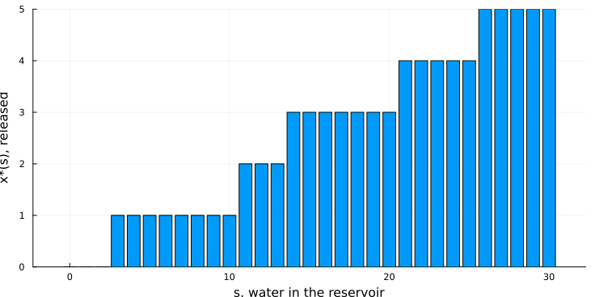

No release below $s = 3$, five units above $s = 25$, and a staircase in between

## Value function

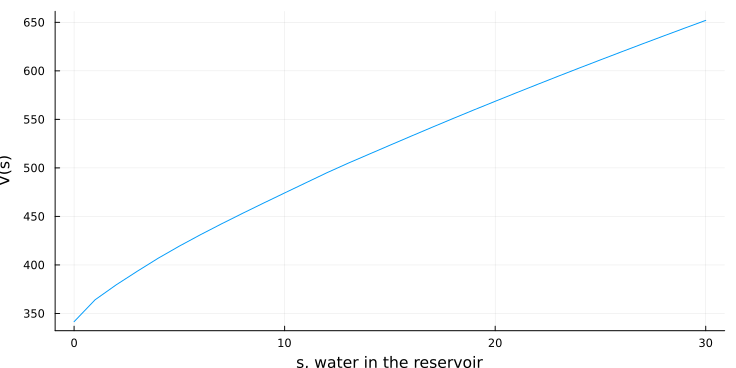

```julia
plot(S, v_vfi; xlabel = "s, water in the reservoir", ylabel = "V(s)", label = false)
```

Increasing and concave: more water is worth more, at a decreasing rate. Hold on to the slope, we come back to it!

## Read the economics off the staircase

```julia
println("policy x*(s) for s = 0, 1, ..., 30: ", x_vfi)
```

```
policy x*(s) for s = 0, 1, ..., 30: [0, 0, 0, 1, 1, 1, 1, 1, 1, 1  …  4, 4, 4, 4, 4, 5, 5, 5, 5, 5]
```

- From $s = 3$ to $s = 30$ the stock rises by 27 units and the release by 4. The release rises with the stock, but far less than one for one
- The reservoir is **buffered, not drained**. Last week’s planner released 93% at $s = 4$. This one releases 1 unit, and 5 out of 30 at a full reservoir

Why? Water left in the reservoir now has a value, $\delta V(s')$

## Break

Eight minutes

# 3. Policy iteration and simulation

## A second method: policy iteration

With a deterministic state transition, given a state $s$ policy $x(s)$, we can determine the next state with certainty

We can organize this as a transition matrix $P^*$, where $P^*[i, j] = 1$ if the policy takes you from stock $S[i]$ to stock $S[j]$, and zero otherwise

With this, we can rewrite the Bellman equation in vector form, with $v$ the vector of $V(s)$ for all $s$:

$$v = \max_{x} \{ f(x) + \delta \, P(x)v \}$$

## Policy iteration embeds an easier linear problem

So we can apply Newton’s method to find the root of this system. The Jacobian is $I - \delta P(x)$, so each iteration requires a linear solve!

The iteration rule from Newton’s method is, starting from a guess $v_0$ and a policy $x_0$:

$$v_{k+1} \leftarrow v_{k} - [I - \delta P(x)]^{-1}[v_{k} - f(x) - \delta P(x)v_{k}]$$

Unlike the full Newton’s method, we only update once. The goal is to speed up convergence, not to solve the optimal policy with a yet incorrect value function

## Policy iteration recipe

0. Initialize: Specify payoff $f(x)$, transition $P(x)$, and an initial guess $v_0$
1. Policy iteration: Given current $v_k$, update policy $x_{k+1} \leftarrow \arg\max_x \{ f(x) + \delta P(x)v_k \}$
2. Update value: Given current policy $x_{k+1}$, update value $v_{k+1} \leftarrow [I - \delta P(x_{k+1})]^{-1} f(x_{k+1})$
3. Check: If $\| v_{k+1} - v_k \| < \text{tol}$, stop. Otherwise, go to step 1.

## Code (given in the script)

```julia
function policy_iteration(f, g; maxit = 100)
    x_pol = zeros(Int, n)             # starting guess: release nothing
    v = zeros(n)
    for it in 1:maxit
        P_star = zeros(n, n)
        f_star = zeros(n)
        for i in 1:n
            k = x_pol[i] + 1          # index of the release chosen at S[i]
            P_star[i, g[i, k]] = 1.0  # mark the transition to next year's stock
            f_star[i] = f[i, k]
        end
        v = (I - δ * P_star) \ f_star
        x_new = zeros(Int, n)
        for i in 1:n
            best, k_best = findmax(f[i, :] .+ δ .* v[g[i, :]])
            x_new[i] = X[k_best]
        end
        if x_new == x_pol
            return v, x_pol, it
        end
        x_pol = x_new
    end
    return v, x_pol, maxit
end
```

## Run it

```julia
v_pi, x_pi, it_pi = policy_iteration(f, g)
println("policy iteration: ", it_pi, " iterations, function iteration: ", it_vfi)
println("same policy: ", x_pi == x_vfi, "   largest difference in V: ", maximum(abs.(v_pi .- v_vfi)))
```

```
policy iteration: 12 iterations, function iteration: 256
same policy: true   largest difference in V: 8.235474524553865e-10
```

## Simulate forward

Start at $s_1 = 4$, follow the policy, apply the transition, repeat

```julia
function simulate(x_pol, s_1, T)
    path = zeros(Int, T)
    path[1] = s_1
    for t in 1:(T - 1)
        x = x_pol[path[t] + 1]
        path[t + 1] = min(path[t] - x + k_rain, M)
    end
    return path
end
path_4  = simulate(x_vfi, 4, 20)
path_30 = simulate(x_vfi, 30, 20)
println("from s_1 = 4:  ", path_4)
println("from s_1 = 30: ", path_30)
```

```
from s_1 = 4:  [4, 5, 6, 7, 8, 9, 10, 11, 11, 11, 11, 11, 11, 11, 11, 11, 11, 11, 11, 11]
from s_1 = 30: [30, 27, 24, 22, 20, 19, 18, 17, 16, 15, 14, 13, 13, 13, 13, 13, 13, 13, 13, 13]
```

Seven years of climbing, then rest at 11. From a full reservoir, eleven years of drawing down, then rest at 13

## Two starting points, two resting points

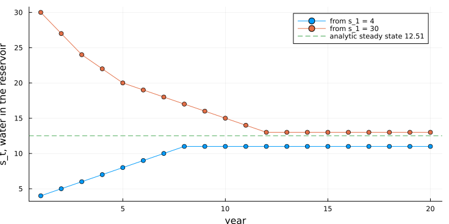

```julia
s_star = 12.513482907674891
plot(1:20, path_4; xlabel = "year", ylabel = "s_t, water in the reservoir", label = "from s_1 = 4", marker = :circle)
plot!(1:20, path_30; label = "from s_1 = 30", marker = :circle)
hline!([s_star]; linestyle = :dash, label = "analytic steady state 12.51")
```

## Which stocks stay put?

A stock is stationary when following the policy brings you back to it

```julia
function stationary_states(x_pol)
    result = zeros(Int, 0)
    for i in 1:n
        if min(S[i] - x_pol[i] + k_rain, M) == S[i]
            push!(result, S[i])
        end
    end
    return result
end
stationary = stationary_states(x_vfi)
println("stationary stocks: ", stationary, "   release there: ", x_vfi[stationary .+ 1])
```

```
stationary stocks: [11, 12, 13]   release there: [2, 2, 2]
```

For all three, the release equals the rain

## This is not a bug

The continuous version of this model has **one** long-run stock, $s^* = 12.51$, where the release equals the rain, $x^* = 2$, and $U'(s^* - x^*) = (1 - \delta) F'(x^*)$

Here the release has to be an integer. $x^*(s) = 2$ is the best choice at $s = 11$, $12$ and $13$, so all three are resting points, and where you end up depends on where you start

Nothing to tune away, this is what a coarse grid does to a smooth problem. You could make the grid finer, but that would require a bit more work indexing the state space; we’ll see a version of that next week

The next session will removes this limitation in two ways: first by making the stock continuous, then by making the rain random. (The homework shows the second one already)

## The missing term, computed

Last week’s promise: at the long-run stock, one more unit of water is worth $\lambda = 0.975 + 8.775 = 9.750$

On a grid, the slope of $V$ is a difference

```julia
λ_grid = v_vfi[14] - v_vfi[13]              # V(13) - V(12)
println("V(13) - V(12) = ", round(λ_grid, digits = 3), "   analytic λ* = 9.750")
```

```
V(13) - V(12) = 9.761   analytic λ* = 9.750
```

$\lambda$ is the shadow price of water in the reservoir. In the next session we read it off a solver directly

## Take it further

`exercises/s2_homework.jl`, solutions in `solutions/`

1. **Put the rain back.** Rain $k \in \{0, 1, 2, 3, 4\}$ with probabilities $(.1, .2, .4, .2, .1)$ (same as in the book). Build the transition probabilities $P[k, i, j]$, take the expectation in the Bellman update, and reproduce the book’s policy and long-run mean stock of 12.5. Then try $k \in \{1, 3\}$ with equal odds: the policy is identical
2. **Where does the plateau go?** With random rain, is any stock stationary? What replaces the question?
3. **Stretch.** Compute the long-run distribution of the stock as the stationary vector of $P^*$ instead of by simulation, and compare

## Next session

1. Julia, optimization, and a static reservoir
2. The Bellman equation on a discrete state
3. **Continuous state: finite and infinite horizon**: the whole horizon as one JuMP model and the shadow price from its duals, then a continuous stock with interpolation, then random rain